# Hobiton Chum assessment review (INTERNAL FOR REFERENCE) - DRAFT

Last update: 2025-12-02

*This document summarizes the current state of biodata available for Hobiton Chum. It is subject to change as more results are received, and data are QC’d.*

# 1 Background

Nitinat River Hatchery conducts a deadpitch program on Hobiton Creek for the purpose of collecting scale and otolith samples to assess age structure and hatchery contribution (respectively). In recent years, Stock Assessment has also been able to help with sample collection; otolith and scale samples are currently covered under StA’s sample allocation (scales analyzed by the A’tlegay lab). Work is also conducted collaboratively with DFN and NTC, depending on crew schedules/availability.

The primary objective for sample collection is to assess the degree of straying from Nitinat Chum that may be occurring in Hobiton, followed by monitoring the age structure. In 2024, approximately 75 DNA samples were also collected as baseline samples for the Molecular Genetics Lab at PBS, with the hopes these samples may help refine the Chum GSI baseline.

Samples are primarily collected via gaff (or beach seine) from a few key locations with pools that accumulate carcasses: for example, the old fence site, the echosounder pool, and the creek mouth (among others). Ideally samples are collected throughout the creek and are representative of the return in time and space.

Table 1.1 summarizes the biodata collections from Hobiton since 2010 for all types of samples.

Table 1.1: Sample sizes of tissues collected from Hobiton Chum since 2010. Years not listed were not sampled. Year in italics represents data not yet in EPRO database added manually.

[output not shown]

# 2 Recent escapements

Hobiton Chum escapement tends to hover around 2000 fish, although timing surveys with environmental conditions is challenging (Fig 2.1). DFN and NTC have operated an echosounder in Hobiton since ~2023 and may have Chum counts not yet in NuSEDS.

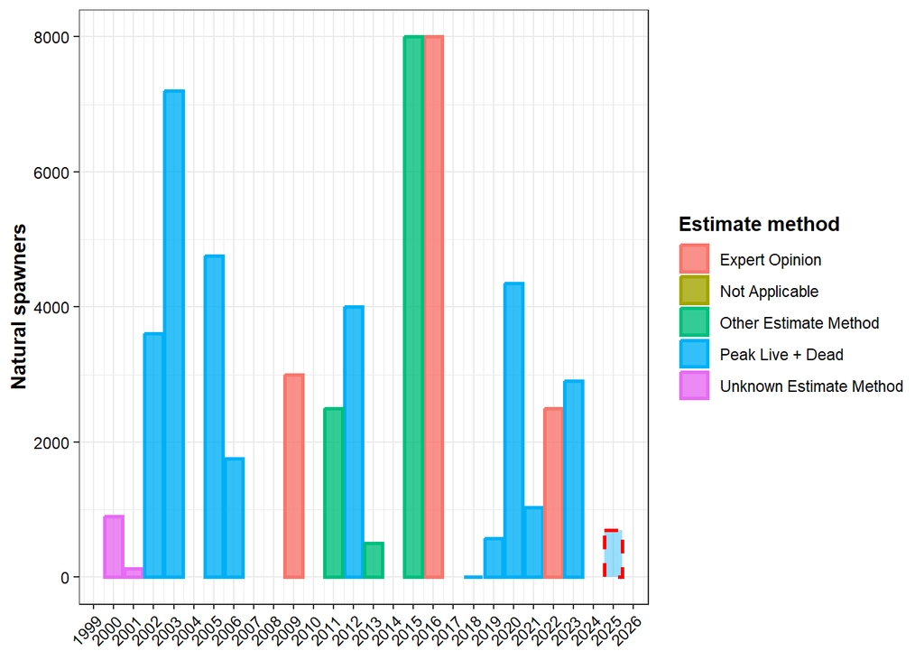

Figure 2.1: Recent Chum escapement to Hobiton Creek coloured by estimate method (an indicator of estimate quality). Value in red dashed indicates preliminary estimate not yet in NuSEDS. Years without bars mean no data are in NuSEDS, but there may be data available from DFN/NTC echosounder counts not yet processed/provided. Data from NuSEDS, Nov 2025.

# 3 Hatchery composition of Hobiton Chum

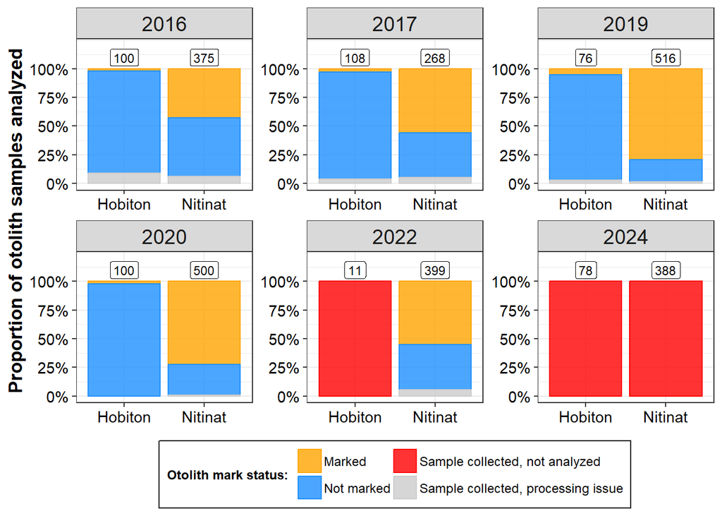

Figure 3.1: Hatchery composition of Hobiton Chum compared to Nitinat Chum for years with collections in both locations. Note that 2025 had a modest sample collection (n=45) but data are not in EPRO at the time this was produced. Samples collected but not analyzed are awaiting analysis at either the Uchucklesaht otolith lab or have been sent to the DFO Yukon otolith lab. Sample sizes for each system are given above each bar.

# 4 Age composition of Hobiton Chum

Coming soon!

# 5 Appendix: Doobah & Caycuse

There is interest in seeding Doobah Creek with Hobiton donor stock (beginning with Chum in particular). Doobah Creek escapements document in NuSEDS are provided in Figure 5.1 for comparison and reference.

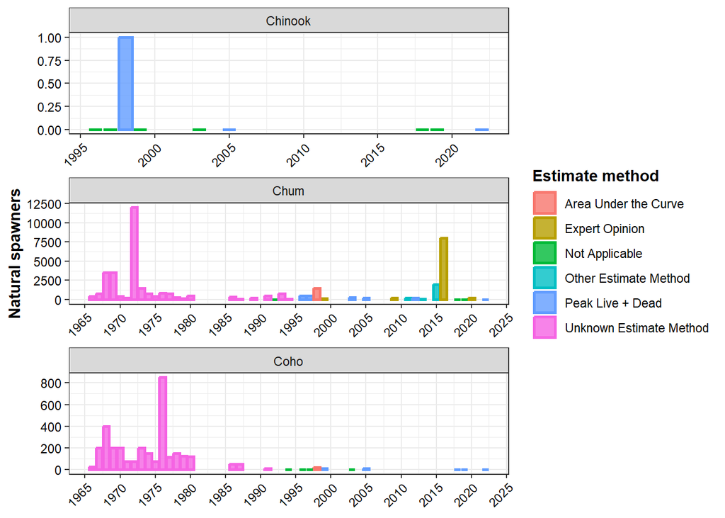

Figure 5.1: Doobah Creek escapement coloured by estimate method (an indicator of estimate quality). Doobah has not been surveyed by DFO in several years. Data from NuSEDS, Nov 2025.

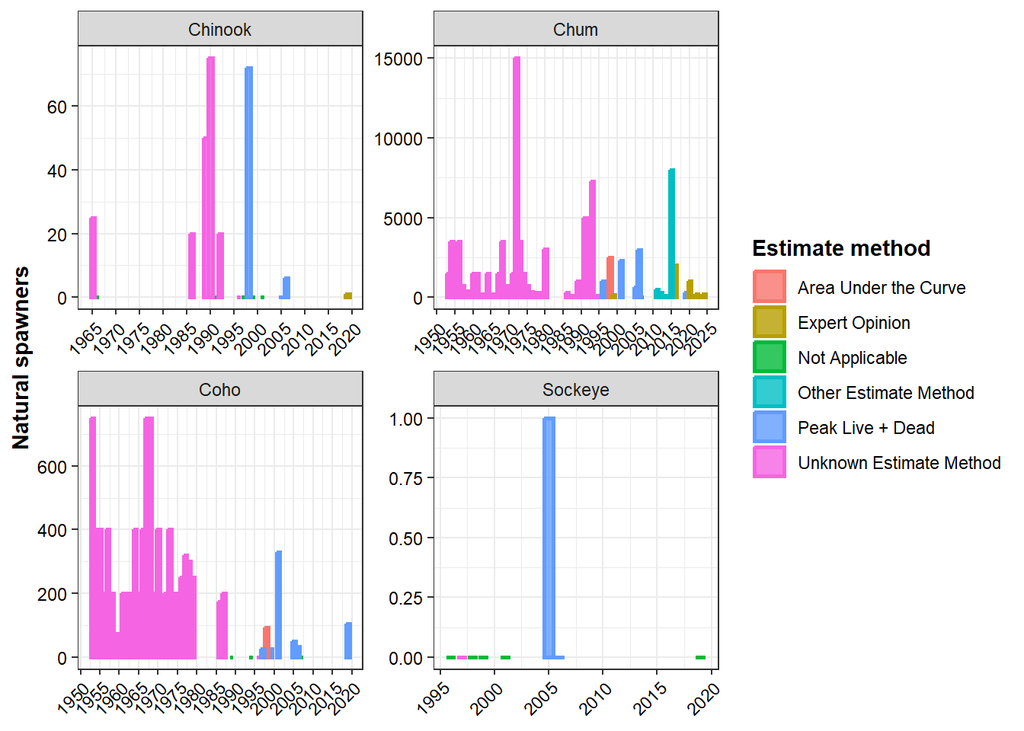